# notebook

## GPA Prediction Model Development

[figure not shown]

In this notebook, we attempt to develop a **Machine Learning Model** that can effectively predict one's GPA primarily using **sklearn**

### Importing libraries

Let's first import our libraries

```python
import pandas as pd
import sklearn

import joblib

from sklearn.model_selection import cross_validate, train_test_split, learning_curve, cross_val_predict, RandomizedSearchCV
from sklearn.pipeline import Pipeline
from sklearn.compose import ColumnTransformer, make_column_selector, TransformedTargetRegressor
from sklearn.base import BaseEstimator, TransformerMixin, clone
from sklearn.preprocessing import OneHotEncoder, StandardScaler, FunctionTransformer, MinMaxScaler
from sklearn.impute import SimpleImputer
from sklearn.metrics import mean_absolute_error as mae, mean_absolute_percentage_error as mape, r2_score as r2, make_scorer

from scipy.stats import percentileofscore
import pandas as pd
from statsmodels.stats.outliers_influence import variance_inflation_factor
from xgboost import XGBRegressor

from sklearn.linear_model import LinearRegression
from sklearn.neighbors import KNeighborsRegressor
from sklearn.ensemble import RandomForestRegressor, HistGradientBoostingRegressor, GradientBoostingRegressor, AdaBoostRegressor, ExtraTreesRegressor
from sklearn.linear_model import Ridge
from sklearn.svm import SVR
from sklearn.tree import DecisionTreeRegressor
from sklearn.inspection import permutation_importance

import seaborn as sns
import numpy as np
import matplotlib.pyplot as plt
sns.set('notebook')

random_state = 21
```

```python
def rmspe(y_true, y_pred):
    error = np.sqrt(np.mean(np.square(((y_true - y_pred) / y_true))))
    return error

rmspe_scorer = make_scorer(
    rmspe,
    greater_is_better=False
)
```

### Dataset

The dataset we'll use comes from the **Student Alcohol Consumption** dataset. [Link](https://www.kaggle.com/datasets/uciml/student-alcohol-consumption)

The metadata can be found in `data/metadata.txt`.

#### Feature Variables

- school - student's school (binary: 'GP' - Gabriel Pereira or 'MS' - Mousinho da Silveira)
- sex - student's sex (binary: 'F' - female or 'M' - male)
- age - student's age (numeric: from 15 to 22)
- address - student's home address type (binary: 'U' - urban or 'R' - rural)
- famsize - family size (binary: 'LE3' - less or equal to 3 or 'GT3' - greater than 3)
- Pstatus - parent's cohabitation status (binary: 'T' - living together or 'A' - apart)
- Medu - mother's education (numeric: 0 - none, 1 - primary education (4th grade), 2 – 5th to 9th grade, 3 – secondary education or 4 – higher education)
- Fedu - father's education (numeric: 0 - none, 1 - primary education (4th grade), 2 – 5th to 9th grade, 3 – secondary education or 4 – higher education)
- Mjob - mother's job (nominal: 'teacher', 'health' care related, civil 'services' (e.g. administrative or police), 'at_home' or 'other')
- Fjob - father's job (nominal: 'teacher', 'health' care related, civil 'services' (e.g. administrative or police), 'at_home' or 'other')
- reason - reason to choose this school (nominal: close to 'home', school 'reputation', 'course' preference or 'other')
- guardian - student's guardian (nominal: 'mother', 'father' or 'other')
- traveltime - home to school travel time (numeric: 1 - <15 min., 2 - 15 to 30 min., 3 - 30 min. to 1 hour, or 4 - >1 hour)
- studytime - weekly study time (numeric: 1 - <2 hours, 2 - 2 to 5 hours, 3 - 5 to 10 hours, or 4 - >10 hours)
- failures - number of past class failures (numeric: n if 1<=n<3, else 4)
- schoolsup - extra educational support (binary: yes or no)
- famsup - family educational support (binary: yes or no)
- paid - extra paid classes within the course subject (Math or Portuguese) (binary: yes or no)
- activities - extra-curricular activities (binary: yes or no)
- nursery - attended nursery school (binary: yes or no)
- higher - wants to take higher education (binary: yes or no)
- internet - Internet access at home (binary: yes or no)
- romantic - with a romantic relationship (binary: yes or no)
- famrel - quality of family relationships (numeric: from 1 - very bad to 5 - excellent)
- freetime - free time after school (numeric: from 1 - very low to 5 - very high)
- goout - going out with friends (numeric: from 1 - very low to 5 - very high)
- Dalc - workday alcohol consumption (numeric: from 1 - very low to 5 - very high)
- Walc - weekend alcohol consumption (numeric: from 1 - very low to 5 - very high)
- health - current health status (numeric: from 1 - very bad to 5 - very good)
- absences - number of school absences (numeric: from 0 to 93)
- These grades are related with the course subject, Math or Portuguese:

#### Target Variable

- G1 - first period grade (numeric: from 0 to 20)
- G2 - second period grade (numeric: from 0 to 20)
- G3 - final grade (numeric: from 0 to 20, output target)

```python
math_df = pd.read_csv('data/student-mat.csv')
lang_df = pd.read_csv('data/student-por.csv')
```

There appears to be two datasets, one for math scores and one for languages scores. Let's inspect the math dataset first.

```python
math_df.describe()
```

|  | age | Medu | Fedu | traveltime | studytime | failures | famrel | freetime | goout | Dalc | Walc | health | absences | G1 | G2 | G3 |
| --- | --- | --- | --- | --- | --- | --- | --- | --- | --- | --- | --- | --- | --- | --- | --- | --- |
| count | 395.000000 | 395.000000 | 395.000000 | 395.000000 | 395.000000 | 395.000000 | 395.000000 | 395.000000 | 395.000000 | 395.000000 | 395.000000 | 395.000000 | 395.000000 | 395.000000 | 395.000000 | 395.000000 |
| mean | 16.696203 | 2.749367 | 2.521519 | 1.448101 | 2.035443 | 0.334177 | 3.944304 | 3.235443 | 3.108861 | 1.481013 | 2.291139 | 3.554430 | 5.708861 | 10.908861 | 10.713924 | 10.415190 |
| std | 1.276043 | 1.094735 | 1.088201 | 0.697505 | 0.839240 | 0.743651 | 0.896659 | 0.998862 | 1.113278 | 0.890741 | 1.287897 | 1.390303 | 8.003096 | 3.319195 | 3.761505 | 4.581443 |
| min | 15.000000 | 0.000000 | 0.000000 | 1.000000 | 1.000000 | 0.000000 | 1.000000 | 1.000000 | 1.000000 | 1.000000 | 1.000000 | 1.000000 | 0.000000 | 3.000000 | 0.000000 | 0.000000 |
| 25% | 16.000000 | 2.000000 | 2.000000 | 1.000000 | 1.000000 | 0.000000 | 4.000000 | 3.000000 | 2.000000 | 1.000000 | 1.000000 | 3.000000 | 0.000000 | 8.000000 | 9.000000 | 8.000000 |
| 50% | 17.000000 | 3.000000 | 2.000000 | 1.000000 | 2.000000 | 0.000000 | 4.000000 | 3.000000 | 3.000000 | 1.000000 | 2.000000 | 4.000000 | 4.000000 | 11.000000 | 11.000000 | 11.000000 |
| 75% | 18.000000 | 4.000000 | 3.000000 | 2.000000 | 2.000000 | 0.000000 | 5.000000 | 4.000000 | 4.000000 | 2.000000 | 3.000000 | 5.000000 | 8.000000 | 13.000000 | 13.000000 | 14.000000 |
| max | 22.000000 | 4.000000 | 4.000000 | 4.000000 | 4.000000 | 3.000000 | 5.000000 | 5.000000 | 5.000000 | 5.000000 | 5.000000 | 5.000000 | 75.000000 | 19.000000 | 19.000000 | 20.000000 |

We observe:

1. There are a total of **395 datapoints**
2. There are three different labels for grades
3. The oldest age appears to be **22**
4. There are columns such as `famrel`, `freetime`, `goout` to name a few, that appear to range from 1 to 5.

Next, let's take a look at the language dataset.

```python
lang_df.describe()
```

|  | age | Medu | Fedu | traveltime | studytime | failures | famrel | freetime | goout | Dalc | Walc | health | absences | G1 | G2 | G3 |
| --- | --- | --- | --- | --- | --- | --- | --- | --- | --- | --- | --- | --- | --- | --- | --- | --- |
| count | 649.000000 | 649.000000 | 649.000000 | 649.000000 | 649.000000 | 649.000000 | 649.000000 | 649.000000 | 649.000000 | 649.000000 | 649.000000 | 649.000000 | 649.000000 | 649.000000 | 649.000000 | 649.000000 |
| mean | 16.744222 | 2.514638 | 2.306626 | 1.568567 | 1.930663 | 0.221880 | 3.930663 | 3.180277 | 3.184900 | 1.502311 | 2.280431 | 3.536210 | 3.659476 | 11.399076 | 11.570108 | 11.906009 |
| std | 1.218138 | 1.134552 | 1.099931 | 0.748660 | 0.829510 | 0.593235 | 0.955717 | 1.051093 | 1.175766 | 0.924834 | 1.284380 | 1.446259 | 4.640759 | 2.745265 | 2.913639 | 3.230656 |
| min | 15.000000 | 0.000000 | 0.000000 | 1.000000 | 1.000000 | 0.000000 | 1.000000 | 1.000000 | 1.000000 | 1.000000 | 1.000000 | 1.000000 | 0.000000 | 0.000000 | 0.000000 | 0.000000 |
| 25% | 16.000000 | 2.000000 | 1.000000 | 1.000000 | 1.000000 | 0.000000 | 4.000000 | 3.000000 | 2.000000 | 1.000000 | 1.000000 | 2.000000 | 0.000000 | 10.000000 | 10.000000 | 10.000000 |
| 50% | 17.000000 | 2.000000 | 2.000000 | 1.000000 | 2.000000 | 0.000000 | 4.000000 | 3.000000 | 3.000000 | 1.000000 | 2.000000 | 4.000000 | 2.000000 | 11.000000 | 11.000000 | 12.000000 |
| 75% | 18.000000 | 4.000000 | 3.000000 | 2.000000 | 2.000000 | 0.000000 | 5.000000 | 4.000000 | 4.000000 | 2.000000 | 3.000000 | 5.000000 | 6.000000 | 13.000000 | 13.000000 | 14.000000 |
| max | 22.000000 | 4.000000 | 4.000000 | 4.000000 | 4.000000 | 3.000000 | 5.000000 | 5.000000 | 5.000000 | 5.000000 | 5.000000 | 5.000000 | 32.000000 | 19.000000 | 19.000000 | 19.000000 |

We observe:

1. The language dataset has **many more datapoints compared to the math dataset** at 649
2. The ages of 22 are also the maximum in this dataset

### Exploratory Data Analysis

Let's get to understanding and getting to know our dataset better.

#### Are there any missing values in the dataset?

We first attempt to identiy if there are any missing values in the dataset

```python
print("Missing values in the math dataset:", math_df.isnull().sum().sum())
print("Missing values in the language dataset:", lang_df.isnull().sum().sum())
```

```
Missing values in the math dataset: 0
Missing values in the language dataset: 0
```

#### Are there duplicate rows in the datasets?

Next, we want to determine if **there are duplicate rows in the datasets**. This is a concern as if there are duplicate rows, data leakage into the test and validation dataset are highly likely, leading to us developing a data-leakage-affected model.

```python
# We drop our labels
math_X = math_df.drop(['G1', 'G2', 'G3', 'paid'], axis=1)
lang_X = lang_df.drop(['G1', 'G2', 'G3', 'paid'], axis=1)
print("Duplicate rows in math:", math_X.duplicated().sum())
print("Duplicate rows in lang:", lang_X.duplicated().sum())
```

```
Duplicate rows in math: 0
Duplicate rows in lang: 0
```

There appears to be no duplicated rows in math or language. But what about students that appear in both datasets?

```python
pd.concat([math_X, lang_X]).duplicated().sum()
```

```
85
```

We see that there are **85** students that appear in both datasets. Let's find out the relationship between math and language scores.

#### What is the relationship between math and language scores?

```python
is_dupe_lang = pd.concat([math_X, lang_X]).duplicated()
is_dupe_math = pd.concat([lang_X, math_X]).duplicated()
lang_dupe_idx = pd.concat([math_X, lang_X])[is_dupe_lang].index
math_dupe_idx = pd.concat([lang_X, math_X])[is_dupe_math].index
```

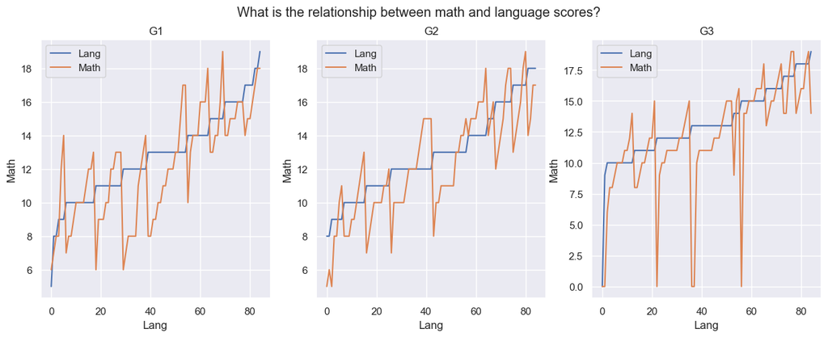

```python
fig = plt.figure(figsize=(15, 5))
fig.suptitle('What is the relationship between math and language scores?')
ax = plt.subplot(1, 3, 1)
ax.plot(sorted(zip(
	lang_df.loc[lang_dupe_idx]['G1'],
	math_df.loc[math_dupe_idx]['G1']
)), label = ['Lang', 'Math'])
ax.set_xlabel('Lang')
ax.set_ylabel('Math')
ax.set_title('G1')
plt.legend()

ax = plt.subplot(1, 3, 2)
ax.plot(sorted(zip(
	lang_df.loc[lang_dupe_idx]['G2'],
	math_df.loc[math_dupe_idx]['G2']
)), label = ['Lang', 'Math'])
ax.set_xlabel('Lang')
ax.set_ylabel('Math')
ax.set_title('G2')
plt.legend()

ax = plt.subplot(1, 3, 3)
ax.plot(sorted(zip(
	lang_df.loc[lang_dupe_idx]['G3'],
	math_df.loc[math_dupe_idx]['G3']
)), label = ['Lang', 'Math'])
ax.set_xlabel('Lang')
ax.set_ylabel('Math')
ax.set_title('G3')
plt.legend()
```

```python
print("G1 - Correlation Coef:",np.corrcoef(lang_df.loc[lang_dupe_idx]['G1'], math_df.loc[math_dupe_idx]['G1'])[0][1])
print("G2 - Correlation Coef:",np.corrcoef(lang_df.loc[lang_dupe_idx]['G2'], math_df.loc[math_dupe_idx]['G2'])[0][1])
print("G3 - Correlation Coef:",np.corrcoef(lang_df.loc[lang_dupe_idx]['G3'], math_df.loc[math_dupe_idx]['G3'])[0][1])
```

```
G1 - Correlation Coef: 0.6994008443527849
G2 - Correlation Coef: 0.7656880483996671
G3 - Correlation Coef: 0.6246591496789441
```

Let's make a new label separating the two different subjects

```python
lang_df['is_math'] = 0
math_df['is_math'] = 1

data_df = pd.concat([lang_df, math_df])
```

#### What is the relationship between `G1`, `G2` and `G3`?

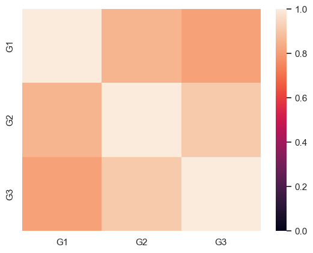

```python
sns.heatmap(data_df[['G1', 'G2', 'G3']].corr(), vmin = 0, vmax = 1)
```

We observe there to be a high correlation between G1, G2 and G3.

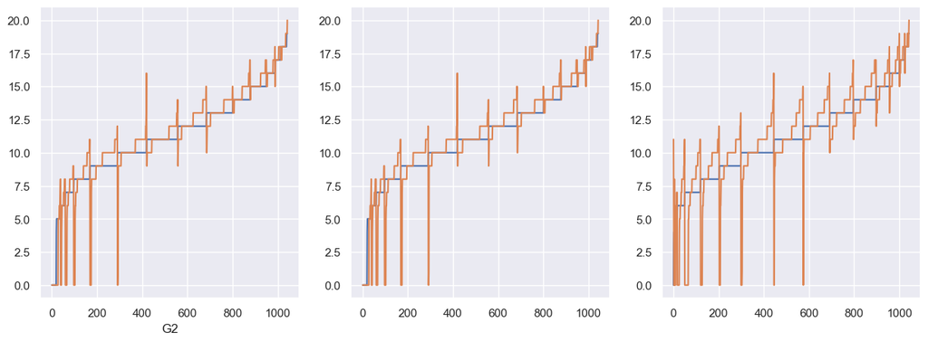

```python
fig = plt.figure(figsize=(15, 5))

ax = plt.subplot(1, 3, 1)
ax.plot(sorted(zip(data_df['G2'], data_df['G3'])))
ax.set_xlabel('G2')
ax = plt.subplot(1, 3, 2)
ax.plot(sorted(zip(data_df['G2'], data_df['G3'])))
ax = plt.subplot(1, 3, 3)
ax.plot(sorted(zip(data_df['G1'], data_df['G3'])))
```

We observe that there are a quite a few students whose grades drop to 0 while other grades score quite high. This anomaly may be due to them joining or leaving school at times before the assessment occurred. As such **we should deal with this 0 in feature engineering**

#### Holdout Set

Before we proceed further, we'll split the data into a train set and a holdout set to prevent data leakage

```python
X_train, X_test, y_train, y_test = train_test_split(data_df.drop(['G1', 'G2', 'G3'], axis=1), data_df[['G1', 'G2', 'G3']], test_size=0.2, random_state = random_state, shuffle=True)
```

### Feature Engineering

#### Students scoring 0

Firstly, we observed that students scored 0 in certain grades. It is very unlikely that students scored 0, and more likely that they left school or changed school during that time, and as such the assessment did not capture their performance. As such we'll average across grades where the grade isn't 0.

```python
# As we have observed from EDA, it is unlikely
def calc_grade(df_pass):
	df = df_pass.copy()
	# df = df.apply(lambda x: x.max(axis=0), axis=1)
	count = df.apply(lambda x: int(x['G1'] > 0) + int(x['G2'] > 0) + int(x['G3'] > 0), axis=1)
	df = df.sum(axis=1) / count
	return df

grades_train = calc_grade(y_train)
grades_test = calc_grade(y_test)
```

#### 20 point system to 4.0 GPA

```python
def to_percentile(series):
	return series.apply(lambda x: percentileofscore(sorted(series), x))

# NUS Bell Curve formula taken from https://blog.nus.edu.sg/provost/2012/01/20/the-bell-curve/
percentile_reg = RandomForestRegressor(n_estimators = 1000)
percentile = np.array([0.0016, 0.0016, 0.0016, 0.0381, 0.1397, 0.1794, 0.2048, 0.1921, 0.1429, 0.0698, 0.0286])
percentile = np.cumsum(percentile)
gpa = np.array([0, 1.0, 1.3, 2.0, 2.4, 2.7, 3.0, 3.3, 3.7, 4, 4])
percentile_reg.fit(percentile.reshape((-1, 1)), gpa)

def percentile_to_gpa(percentile):
	if len(percentile.shape) == 1:
		percentile = percentile.values.reshape((-1, 1))
	return percentile_reg.predict(percentile / 100)
```

```python
y_train = percentile_to_gpa(to_percentile(grades_train))
y_test = percentile_to_gpa(to_percentile(grades_test))
```

#### Drop school

As we do not have school information during inference we'll drop the school column.

```python
X_train.drop('school', axis=1, inplace = True)
X_test.drop('school', axis=1, inplace = True)
```

#### Total Alcohol Consumption

```python
X_train['Total_alc'] = (X_train['Dalc'] * X_train['Walc']) ** 0.5
X_test['Total_alc'] = (X_test['Dalc'] * X_test['Walc']) ** 0.5
```

#### Dimensionality Reduction

We want to reduce the number of dimensions to reduce overfitting. As such, let's check for collinearity between the features

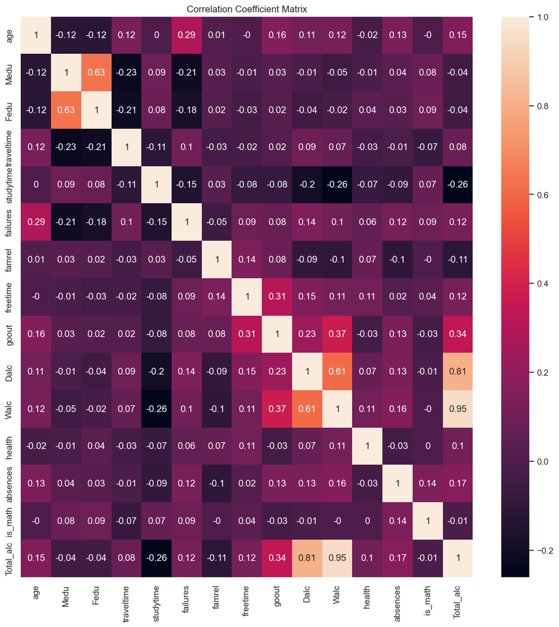

```python
numerical_columns = X_train.columns[X_train.dtypes != 'object']

corr = X_train[numerical_columns].corr(method="spearman").applymap(lambda x: round(x, 2))

fig = plt.figure()
fig.set_size_inches(13, 13)
fig.set_dpi(100)

ax = fig.subplots()

sorted_columns = corr.index.values
temp_corr = pd.DataFrame()
for column in sorted_columns:
	temp_corr = pd.concat([temp_corr, corr[column]], axis=1)

corr = temp_corr

sns.heatmap(corr, xticklabels=corr.columns, yticklabels=corr.columns, annot = True, ax=ax)
plt.title("Correlation Coefficient Matrix")
plt.show()
```

```python
vif = pd.DataFrame()
temp = X_train.copy()
temp = temp.drop(['age', 'Dalc', 'famrel', 'Walc', 'freetime', 'Medu'], axis=1)
numerical_columns = temp.columns[temp.dtypes != 'object']
cat_columns = temp.columns[temp.dtypes == 'object']
vif['VIF'] = [variance_inflation_factor(temp[numerical_columns].values, i) for i in range(temp[numerical_columns].shape[1])]
vif['variable'] = temp[numerical_columns].columns
display(vif.sort_values(by='VIF'))
keep = vif['variable'].values
```

|  | VIF | variable |
| --- | --- | --- |
| 3 | 1.263115 | failures |
| 6 | 1.598023 | absences |
| 7 | 1.691193 | is_math |
| 1 | 4.697707 | traveltime |
| 0 | 5.236542 | Fedu |
| 8 | 5.396915 | Total_alc |
| 2 | 5.452908 | studytime |
| 5 | 6.021366 | health |
| 4 | 8.545581 | goout |

```python
keep_cols = np.concatenate([keep, cat_columns])
```

### Modelling

Let's get to modelling!

```python
from sklearn.compose import make_column_transformer

CategoricalOHE = make_column_transformer((OneHotEncoder(sparse = False), make_column_selector(dtype_include=object)), remainder='passthrough')

preprocessor = Pipeline(steps=[
	('encoding', CategoricalOHE)
])
```

```python
preprocess = Pipeline(steps=[
	('preprocessing', CategoricalOHE),
	('scaler', StandardScaler()),
])
```

```python
def show_learning_curve(model, X, y, ax):
    folds = 3
    train_size, train_scores, valid_scores = learning_curve(model, X, y, train_sizes=np.linspace(0.1,1,5), scoring='neg_mean_absolute_percentage_error', cv=folds)
    size = np.repeat(train_size, repeats=folds)
    train_score = train_scores.flatten()
    test_score = valid_scores.flatten()
    df = pd.DataFrame({
        'Train Size': size, 'Train Scores': train_score, 'Test Scores': test_score
    })
    new_df = df.melt(['Train Size'])
    new_df = new_df.sort_values(by=['Train Size', 'variable'], ascending=[True, False])
    new_df.columns = ['Train Size', 'Type', 'Error (MAPE)']
    sns.lineplot(data=new_df, x='Train Size', y='Error (MAPE)', hue='Type', ax=ax, palette=sns.color_palette()[0:2])
    ax.set_title('Learning Curve')

def show_scatter(y_true, y_pred, scatterAx):
    flat_y_true = np.array(y_true).flatten()
    flat_y_pred = y_pred.flatten()
    sns.scatterplot(x=flat_y_true, y=y_pred, ax=scatterAx)
    limits = [0, max(max(flat_y_true), max(flat_y_pred))]
    scatterAx.set_title('Prediction Scatterplot')
    scatterAx.set_xlabel('True GPA')
    scatterAx.set_ylabel('Predicted GPA')
    scatterAx.plot(limits, limits, color=sns.color_palette('Set2')[1])

def get_model_performance(y_true, y_pred, y_train_pred, model_name, train_scores=True):
    flat_y_true = np.array(y_true).flatten()
    flat_y_pred = y_pred.flatten()
    flat_y_train_pred = y_train_pred.flatten()

    metrics = {
        'Train RMSPE': rmspe(flat_y_true, flat_y_train_pred),
        'Test RMSPE': rmspe(flat_y_true, flat_y_pred),
        'Train MAE': mae(flat_y_true, flat_y_train_pred),
        'Test MAE': mae(flat_y_true, flat_y_pred),
        'Train MAPE': mape(flat_y_true, flat_y_train_pred),
        'Test MAPE': mape(flat_y_true, flat_y_pred)
    }

    return pd.DataFrame([metrics], index=[model_name])

def assess_model(model, X, y, name=None, plot_show = True):
    if (name == None):
        name = type(model).__name__
    if plot_show:
        fig = plt.figure(figsize=(14, 6))
        fig.suptitle(name, fontsize=15)

        subplots = fig.subplots(1, 2)
        ax = subplots[0]


        scatterAx = subplots[1]
        scatterAx.axis('equal')

    if plot_show:
        show_learning_curve(model, X, y, ax)
        ax.set_ylim(-1, 0)

    test_predictions = cross_val_predict(model, X, y, cv=5)

    model_copy = clone(model)
    model_copy.fit(X, y)
    train_predictions = model_copy.predict(X)


    if plot_show:
        show_scatter(y, test_predictions, scatterAx)
    model_performance = get_model_performance(y, test_predictions, train_predictions, name)

    if plot_show:
        display(model_performance)
        plt.show()

    return model_performance
```

```python
transformed_X_train = preprocess.fit_transform(X_train, y_train)
transformed_X_test = preprocess.transform(X_test)
```

#### `Linear Regression`

|  | Train RMSPE | Test RMSPE | Train MAE | Test MAE | Train MAPE | Test MAPE |
| --- | --- | --- | --- | --- | --- | --- |
| LinearRegression | 0.316702 | 0.332579 | 0.43793 | 0.461546 | 0.180376 | 0.189462 |

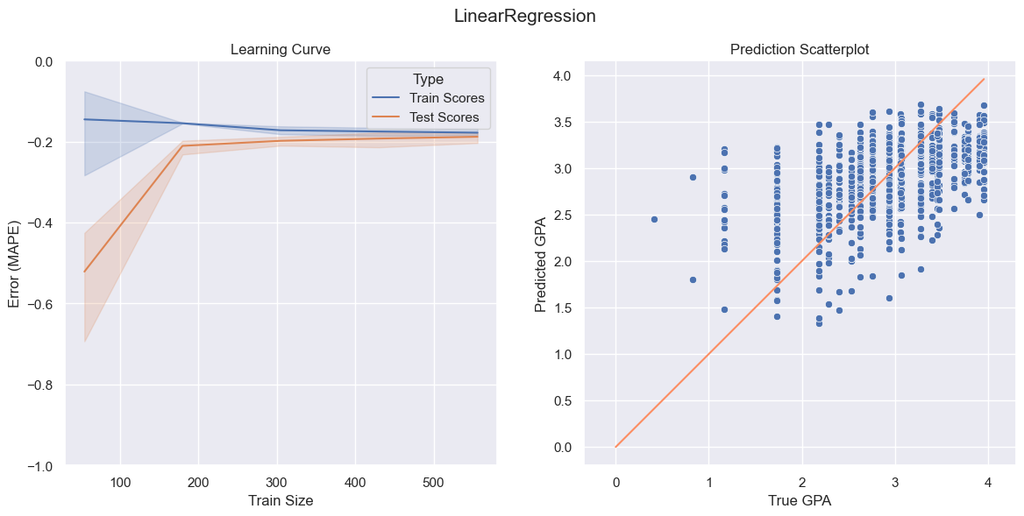

```python
results = assess_model(LinearRegression(), transformed_X_train, y_train)
summary = results
```

#### `Decision Tree Regressor`

|  | Train RMSPE | Test RMSPE | Train MAE | Test MAE | Train MAPE | Test MAPE |
| --- | --- | --- | --- | --- | --- | --- |
| DecisionTreeRegressor | 1.620524e-17 | 0.42416 | 4.254747e-18 | 0.615446 | 2.021461e-18 | 0.249268 |

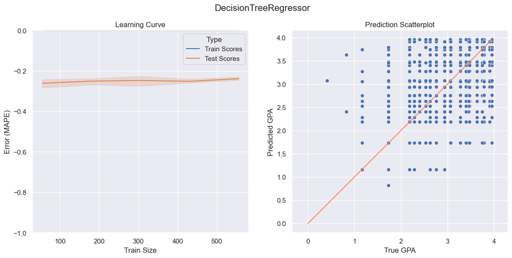

```python
results = assess_model(DecisionTreeRegressor(), transformed_X_train, y_train)
summary = pd.concat([summary, results], axis=0)
```

#### `Ada Boost Regressor`

|  | Train RMSPE | Test RMSPE | Train MAE | Test MAE | Train MAPE | Test MAPE |
| --- | --- | --- | --- | --- | --- | --- |
| AdaBoostRegressor | 0.264373 | 0.328565 | 0.440391 | 0.474651 | 0.173136 | 0.192278 |

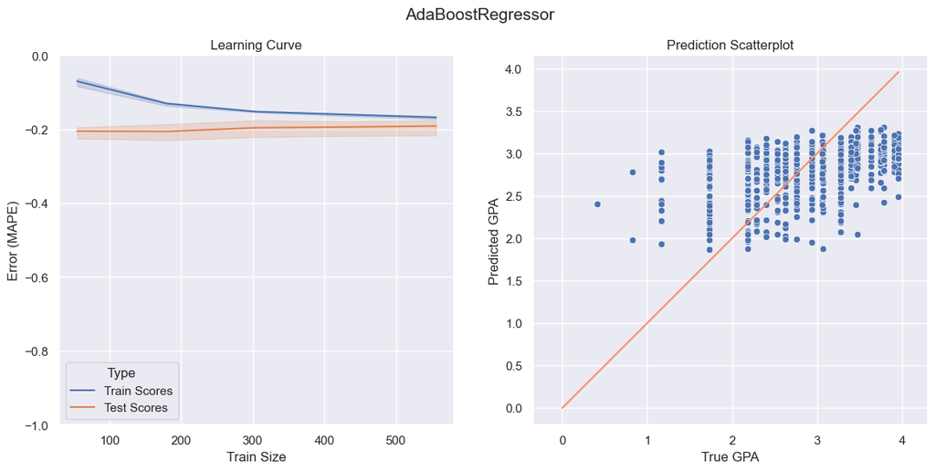

```python
results = assess_model(AdaBoostRegressor(), transformed_X_train, y_train)
summary = pd.concat([summary, results], axis=0)
```

#### `Random Forest Regressor`

|  | Train RMSPE | Test RMSPE | Train MAE | Test MAE | Train MAPE | Test MAPE |
| --- | --- | --- | --- | --- | --- | --- |
| RandomForestRegressor | 0.114453 | 0.316166 | 0.16272 | 0.437141 | 0.066314 | 0.179168 |

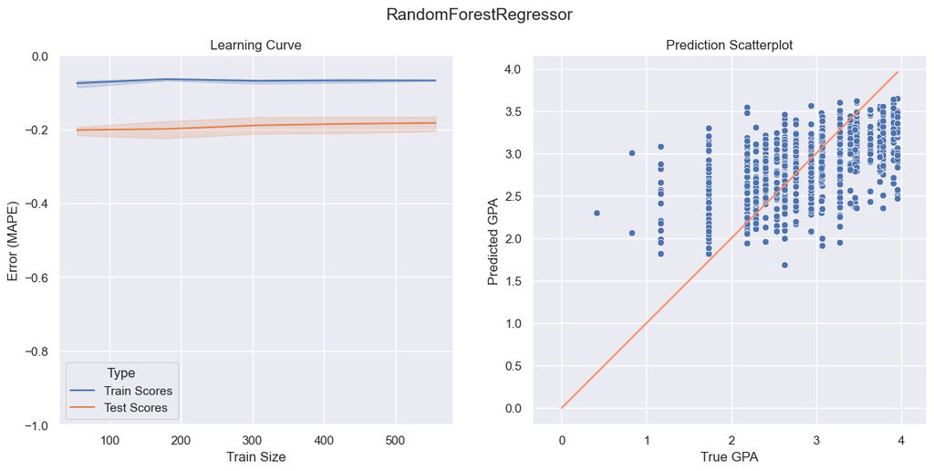

```python
results = assess_model(RandomForestRegressor(), transformed_X_train, y_train)
summary = pd.concat([summary, results], axis=0)
```

#### `Extreme-Gradient Boosting Regressor`

|  | Train RMSPE | Test RMSPE | Train MAE | Test MAE | Train MAPE | Test MAPE |
| --- | --- | --- | --- | --- | --- | --- |
| XGBRegressor | 0.021451 | 0.297127 | 0.025265 | 0.440042 | 0.00982 | 0.178276 |

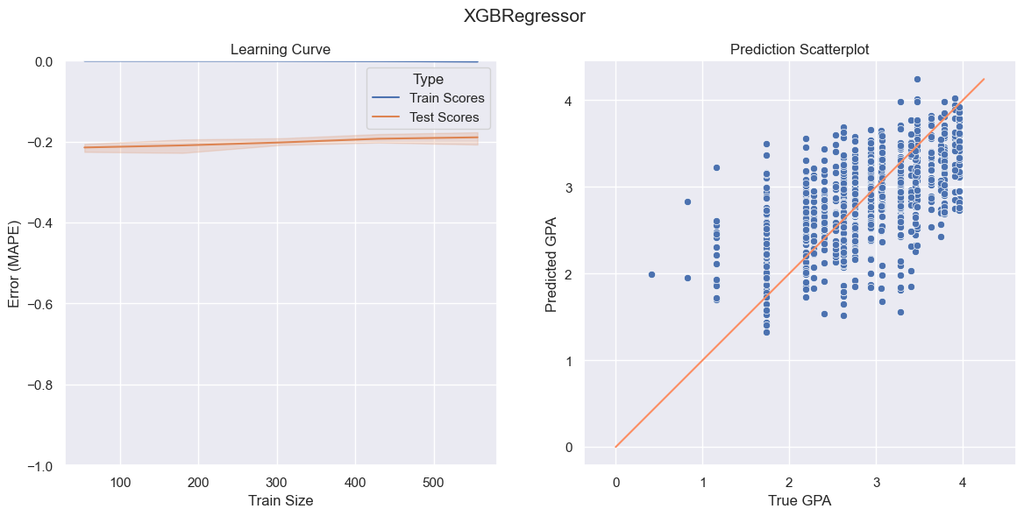

```python
xgb_results = assess_model(XGBRegressor(), transformed_X_train, y_train)
summary = pd.concat([summary, xgb_results], axis=0)
```

#### `Histogram Gradient Boosting Regressor`

|  | Train RMSPE | Test RMSPE | Train MAE | Test MAE | Train MAPE | Test MAPE |
| --- | --- | --- | --- | --- | --- | --- |
| HistGradientBoostingRegressor | 0.113139 | 0.310159 | 0.161021 | 0.437066 | 0.065317 | 0.178506 |

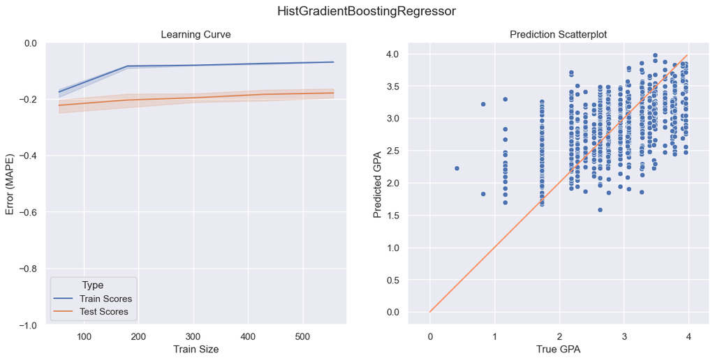

```python
hgb_results = assess_model(HistGradientBoostingRegressor(), transformed_X_train, y_train)
summary = pd.concat([summary, hgb_results], axis=0)
```

#### `Ridge Regressor`

|  | Train RMSPE | Test RMSPE | Train MAE | Test MAE | Train MAPE | Test MAPE |
| --- | --- | --- | --- | --- | --- | --- |
| Ridge | 0.314508 | 0.329219 | 0.433193 | 0.458081 | 0.178098 | 0.187911 |

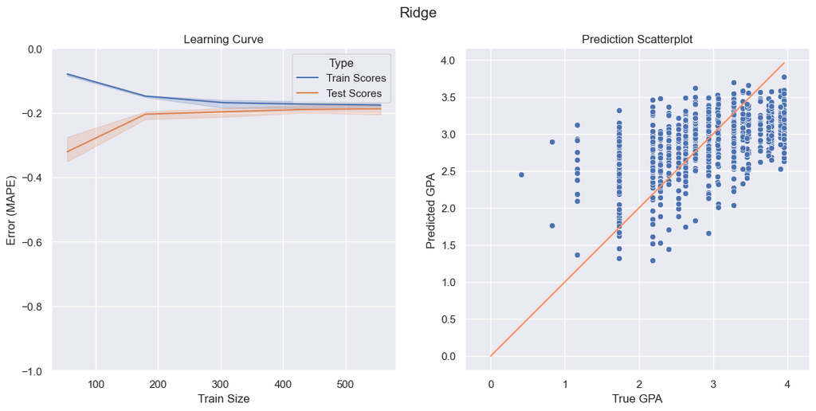

```python
results = assess_model(Ridge(), transformed_X_train, y_train)
summary = pd.concat([summary, results], axis=0)
```

#### `KNeighbors Regressor`

|  | Train RMSPE | Test RMSPE | Train MAE | Test MAE | Train MAPE | Test MAPE |
| --- | --- | --- | --- | --- | --- | --- |
| KNeighborsRegressor | 0.310412 | 0.393443 | 0.377723 | 0.487494 | 0.162526 | 0.207915 |

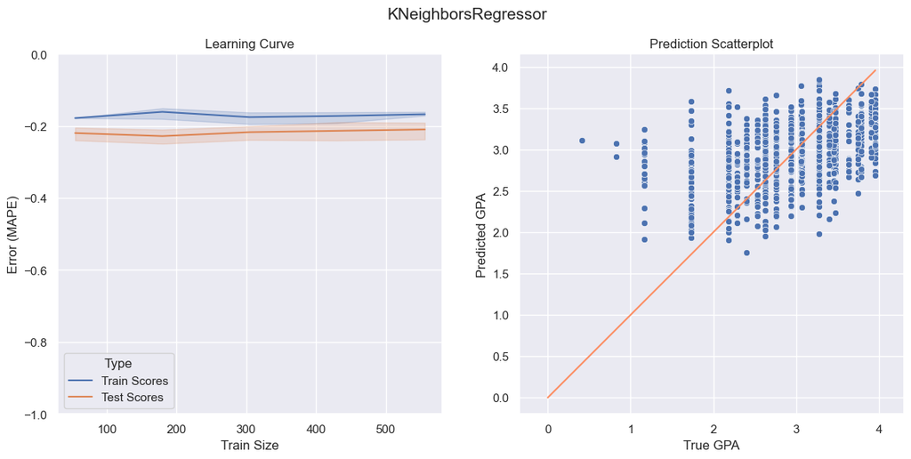

```python
results = assess_model(KNeighborsRegressor(), transformed_X_train, y_train)
summary = pd.concat([summary, results], axis=0)
```

```python
def show_summary(summary, train=False):

    train_columns = [column for column in summary.columns if 'Train' in column]
    test_columns = [column for column in summary.columns if 'Test' in column]

    df = summary.copy()
    if (not train):
        df.drop(train_columns, inplace=True, axis=1)

    return df.sort_values(by=test_columns)

show_summary(summary)
```

|  | Test RMSPE | Test MAE | Test MAPE |
| --- | --- | --- | --- |
| XGBRegressor | 0.297127 | 0.440042 | 0.178276 |
| HistGradientBoostingRegressor | 0.310159 | 0.437066 | 0.178506 |
| RandomForestRegressor | 0.316166 | 0.437141 | 0.179168 |
| AdaBoostRegressor | 0.328565 | 0.474651 | 0.192278 |
| Ridge | 0.329219 | 0.458081 | 0.187911 |
| LinearRegression | 0.332579 | 0.461546 | 0.189462 |
| KNeighborsRegressor | 0.393443 | 0.487494 | 0.207915 |
| DecisionTreeRegressor | 0.424160 | 0.615446 | 0.249268 |

### Model Improvement

Now we can focus on improving our model. We see that the models **HistGradientBoosting, Extreme Gradient Boosting and Random Forest** are all strong base models.

```python
base_models = [HistGradientBoostingRegressor, XGBRegressor, RandomForestRegressor]
```

#### Log Transforming the Target

We'll try log transforming the target

```python
transform_models = {}
names = ["HGB", "XGB", "RF"]

for i, model in enumerate(base_models):
    transform_models[f'LTT + {names[i]}'] = TransformedTargetRegressor(
            model(random_state = random_state),
            func = np.log1p,
            inverse_func = np.expm1
        )
```

#### MinMax LogTransforming Target

Another method of log transforming the target is performing **MinMax LogTransforming the target**.

```python
from utils import TwoTransformers

for i, model in enumerate(base_models):
    transform_models[f'MMLTT + {names[i]}'] = TransformedTargetRegressor(
            model(random_state = random_state),
            transformer=TwoTransformers()
        )
```

#### Applying Dimensionality Reduction

We also should try to reduce the dimension.

```python
cols = [X_train.columns, keep_cols]
```

```python
if False:
	for i, col in enumerate(cols):
		for name, model in transform_models.items():
			preprocess = Pipeline(steps=[
				('column_fix', ColumnFixer()),
				('preprocessing', CategoricalOHE),
				('scaler', StandardScaler()),
			])
			results = assess_model(model, preprocess.fit_transform(X_train[col]), y_train, name = f"{name} + DM = {i}", plot_show = False)
			summary = pd.concat([summary, results], axis=0)

	show_summary(summary)
```

#### Hyperparameter tuning

```python
if False:
	params = {
		'regressor__max_iter': np.arange(50, 550, 50),
		'regressor__max_leaf_nodes': np.arange(5, 55, 10),
		'regressor__max_depth': [None] + np.arange(5, 17, 2).tolist(),
		'regressor__min_samples_leaf': [20],
		'regressor__l2_regularization': [1, 0.1, 0.01, 0.001, 0],
		'regressor__max_bins': np.arange(50, 255, 10),
		'regressor__early_stopping': [False, True, 'auto'],
	}

	mmltt_hgb = TransformedTargetRegressor(
			HistGradientBoostingRegressor(random_state = random_state),
			transformer=TwoTransformers()
		)

	cv = RandomizedSearchCV(mmltt_hgb, params, n_iter=1000, random_state=random_state, n_jobs = -1, refit = False)

	preprocess = Pipeline(steps=[
		('column_fix', ColumnFixer()),
		('preprocessing', CategoricalOHE),
		('scaler', StandardScaler()),
	])

	cv.fit(preprocess.fit_transform(X_train[keep_cols]), y_train)
	cv.best_params_
```

### Final Model

Let's assess our final model on the test set

```python
model = TransformedTargetRegressor(
	HistGradientBoostingRegressor(
		min_samples_leaf = 20,
		max_leaf_nodes = 15,
		max_iter = 150,
		max_depth = 9,
		max_bins = 200,
		l2_regularization = 1,
		early_stopping = False,
		random_state = 21
	),
	transformer=TwoTransformers()
)
```

#### Feature Importance

We'll determine the feature importance, so that we can determine which columns are useful in predicting and which are not. This will allow us to minimize the number of questions we have to ask the user.

```
MAE: 0.4014720683580086
```

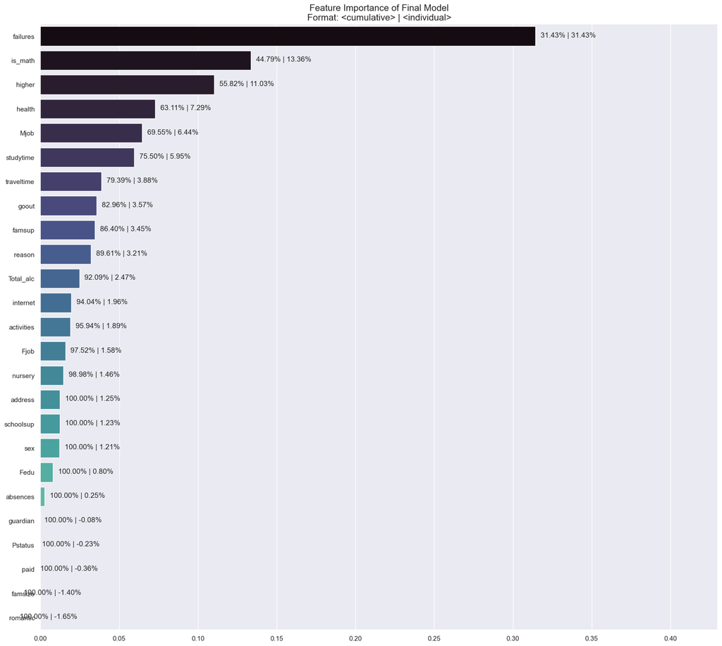

```python
preprocess = Pipeline(steps=[
	('preprocessing', CategoricalOHE),
	('scaler', StandardScaler()),
])

final = Pipeline([
	('preprocess', preprocess),
	('model', model)
])

final.fit(X_train[keep_cols], y_train)
print("MAE:",mae(final.predict(X_test[keep_cols]), y_test))

feat_imp = permutation_importance(final, X_test[keep_cols], y_test, scoring='neg_mean_absolute_percentage_error', random_state=random_state, n_repeats=2)
fig = plt.figure(figsize=(20, 18))
ax = fig.subplots()
sorted_importances = feat_imp.importances_mean.argsort()
sorted_importances = sorted_importances.tolist()[::-1]
total = feat_imp.importances_mean.sum()
mean_imp = feat_imp.importances_mean / total
sns.barplot(x=mean_imp[sorted_importances], y=np.arange(len(X_test[keep_cols].columns)), orient='h', ax=ax, palette=sns.color_palette("mako", n_colors=len(X_test[keep_cols].columns)))
ax.set_yticklabels(X_test[keep_cols].columns[sorted_importances])
ax.set_title("Feature Importance of Final Model\nFormat: <cumulative> | <individual>", fontsize=15)

cumsum = mean_imp[sorted_importances].cumsum()
[ax.text(mean_imp[sorted_importances][i] + float(ax.get_xlim()[1]) * 0.01, i + 0.05, f"{min(100, cumsum[i] * 100):.2f}% | {mean_imp[sorted_importances][i] * 100:.2f}%") for i in range(len(X_test[keep_cols].columns))]
ax.set_xlim(0, ax.set_xlim()[1] * 1.3)

plt.show()
```

```python
final_columns = ['failures', 'is_math', 'higher', 'health', 'Mjob', 'studytime', 'goout', 'reason', 'traveltime', 'activities', 'famsup', 'nursery', 'Total_alc']
small_columns = ['failures', 'is_math', 'higher', 'health', 'Mjob', 'studytime', 'goout', 'reason', 'traveltime']
```

```python
model = TransformedTargetRegressor(
	HistGradientBoostingRegressor(
		min_samples_leaf = 20,
		max_leaf_nodes = 15,
		max_iter = 150,
		max_depth = 9,
		max_bins = 200,
		l2_regularization = 1,
		early_stopping = False,
		random_state = 21
	),
	transformer=TwoTransformers()
)

small_model = TransformedTargetRegressor(
	HistGradientBoostingRegressor(
		min_samples_leaf = 20,
		max_leaf_nodes = 15,
		max_iter = 150,
		max_depth = 9,
		max_bins = 200,
		l2_regularization = 1,
		early_stopping = False,
		random_state = 21
	),
	transformer=TwoTransformers()
)

preprocess = Pipeline(steps=[
	('preprocessing', OneHotEncoder(sparse=False)),
	('scaler', StandardScaler()),
])

final = Pipeline([
	('preprocess', preprocess),
	('model', model)
])

small_final = clone(final)

final.fit(X_train[final_columns], y_train)
small_final.fit(X_train[small_columns], y_train)
```

```
Pipeline(steps=[('preprocess',
                 Pipeline(steps=[('preprocessing', OneHotEncoder(sparse=False)),
                                 ('scaler', StandardScaler())])),
                ('model',
                 TransformedTargetRegressor(regressor=HistGradientBoostingRegressor(early_stopping=False,
                                                                                    l2_regularization=1,
                                                                                    max_bins=200,
                                                                                    max_depth=9,
                                                                                    max_iter=150,
                                                                                    max_leaf_nodes=15,
                                                                                    random_state=21),
                                            transformer=TwoTransformers()))])
```

```python
print("Full TEST MAPE:", mape(y_test, final.predict(X_test[final_columns])))
print("Small TEST MAPE:", mape(y_test, small_final.predict(X_test[small_columns])))
```

```
Full TEST MAPE: 0.16549249203634817
Small TEST MAPE: 0.1667642437265685
```

### Saving Model Weights

Finally, let's save the column names we use along with the model weights into pickle files using `joblib`

```python
import cloudpickle

data_df['Total_alc'] = data_df['Dalc'] * data_df['Walc']

final.fit(data_df[final_columns], percentile_to_gpa(to_percentile(calc_grade(data_df[['G1', 'G2', 'G3']]))))
small_final.fit(data_df[final_columns], percentile_to_gpa(to_percentile(calc_grade(data_df[['G1', 'G2', 'G3']]))))

# NOTE: we save the model weights using the python file notebook.py
```

```
Pipeline(steps=[('preprocess',
                 Pipeline(steps=[('preprocessing', OneHotEncoder(sparse=False)),
                                 ('scaler', StandardScaler())])),
                ('model',
                 TransformedTargetRegressor(regressor=HistGradientBoostingRegressor(early_stopping=False,
                                                                                    l2_regularization=1,
                                                                                    max_bins=200,
                                                                                    max_depth=9,
                                                                                    max_iter=150,
                                                                                    max_leaf_nodes=15,
                                                                                    random_state=21),
                                            transformer=TwoTransformers()))])
```